# Caballero Osorio, Fabian Mauricio - Quiz 1 (Week 3) Feedback

| Course | Assessment |
| --- | --- |
| Machine Learning | Quiz 1 (Week 3) |

| Student Name | Student ID |
| --- | --- |
| Caballero Osorio, Fabian Mauricio | S3912233 |

### General Assessment Feedback

Overall, this quiz was handled very well by the vast majority of our students with the class average being in mid-20s out of 30 points. We hope that it served as a good introduction to the quiz environment for this course. For future reference, please be mindful of additional print statements in the code as this will not be overlooked in subsequent quizzes and please be sure to read the questions carefully. Great job everyone!

This being the first quiz, we did not apply any late submission penalties (per the "minutes for points" policy) as a courtesy. However, these penalties will be applied without exceptions in future quizzes. In addition, you can expect the future quizzes to be more demanding and more challenging.

This quiz had the first taste of a challenge question. These will take longer than the other questions for a disproportionate number of marks and will require you to think outside the box. We do not expect all students to answer these correctly or even attempt these questions, so please do not stress about the challenge questions moving forward as there is no real way to prepare for them. In particular, they are designed to be difficult per the time pressure and we encourage students to give them a go outside of the quiz time at their own pace.

### Student Assessment Results & Feedback

Question

Student Answer

Correct Answer

Feedback

Score

Question 1  
(link)  
(2 point(s))

True

True

*************************  
**STUDENT FEEDBACK:**  
*************************  
**Full credit was awarded for this answer.**  
*************************  
**GENERAL FEEDBACK:**  
*************************  
The correct answer is "True". For any answer cell in the questions notebook, you must run the cell so that your answer is recorded correctly for marking purposes.

2.0

Question 2  
(link)  
(2 point(s))

Max project group size is 3.

Max project group size is 3.

*************************  
**STUDENT FEEDBACK:**  
*************************  
**Full credit was awarded for this answer.**  
*************************  
**GENERAL FEEDBACK:**  
*************************  
In this course, max project group size is 3 students. Although you may work in a smaller group or alone. Please be sure to register your group before the deadline!!!

2.0

Question 3  
(link)  
(4 point(s))

```
a = float(input('Waiting for input: '))
b = float(input('Waiting for input: '))

def my_func(a, b):
    ### ADD YOUR CODE BELOW
    a = abs(a)**3
    b = abs(b)**3

    result = a + b

    return result

    ### ADD YOUR CODE ABOVE

print(f"the output is {my_func(a,b):.2f}.")

UNIT TEST RESULTS:
Test 1: Passed! (Successful Test Output: the output is 35.00.)

Test 2: Passed! (Successful Test Output: the output is 35.00.)
```

```
a = float(input('Waiting for input: '))
b = float(input('Waiting for input: '))

def my_func(a, b):
    ### ADD YOUR CODE BELOW

    result = abs(a)**3 + abs(b)**3

    # result = 999

    return result

    ### ADD YOUR CODE ABOVE

print(f"the output is {my_func(a,b):.2f}.")
```

*************************  
**STUDENT FEEDBACK:**  
*************************  
**Full credit was awarded for this answer.**  
*************************  
**GENERAL FEEDBACK:**  
*************************  
This question was answered correctly by the vast majority of students. This was a simple function to code to get everyone familiar with the quiz coding environment.

4.0

Question 4  
(link)  
(2 point(s))

5 calendar days

5 calendar days

*************************  
**STUDENT FEEDBACK:**  
*************************  
**Full credit was awarded for this answer.**  
*************************  
**GENERAL FEEDBACK:**  
*************************  
For any assessment in this course, you must request a recheck within 5 calendar days of the results being published.

2.0

Question 5  
(link)  
(4 point(s))

```
n = int(float(input('Waiting for input: ')))

### REQUIREMENT: the name of your dictionary must be "d"

### ADD YOUR CODE BELOW
d={}
if n > 5:
    for i in range(5,n+1):
        d.update({i:i*2})


### ADD YOUR CODE ABOVE

print(d)

UNIT TEST RESULTS:
Test 1: Passed! (Successful Test Output: {5: 10, 6: 12})
```

```
n = int(float(input('Waiting for input: ')))

### REQUIREMENT: the name of your dictionary must be "d"

### ADD YOUR CODE BELOW

d = dict()
for i in range(5, n+1):
    d[i] = i*2

# d = 999

### ADD YOUR CODE ABOVE

print(d)
```

*************************  
**STUDENT FEEDBACK:**  
*************************  
**Full credit was awarded for this answer.**  
*************************  
**GENERAL FEEDBACK:**  
*************************  
Another question handled well by the vast majority of students. A common mistake was setting the dictionary values to be multiples of n rather than 2 as specified by the question. Please ensure you read the questions carefully!

4.0

Question 6  
(link)  
(2 point(s))

Regular RMIT email

Regular RMIT email

*************************  
**STUDENT FEEDBACK:**  
*************************  
**Full credit was awarded for this answer.**  
*************************  
**GENERAL FEEDBACK:**  
*************************  
The proper was to communicate with course staff in this course is via regular university email. Thank you.

2.0

Question 7  
(link)  
(4 point(s))

```
# get the user input string
input_string = input('Waiting for input: ')  # example: abcd (without any spaces or commas in between)

# split the user input string into a list
string = [letter for letter in input_string]

### ADD YOUR CODE BELOW
L=list()
for i in string:
    L.append(i)
C = sorted(L)

a = len(C)%2
if a > 0:
    b = round(len(C)/2)
else:
    b = (round(len(C)/2))-1


middle_letter = C[b]

### ADD YOUR CODE ABOVE

print(f"The alphabetical middle letter is {middle_letter}.")

UNIT TEST RESULTS:
Test 1: Passed! (Successful Test Output: The alphabetical middle letter is k.)

Test 2: Passed! (Successful Test Output: The alphabetical middle letter is l.)

Test 3: Passed! (Successful Test Output: The alphabetical middle letter is m.)
```

```
# get the user input string
input_string = input('Waiting for input: ')  # example: abcd (without any spaces or commas in between)

# split the user input string into a list
string = [letter for letter in input_string]

### ADD YOUR CODE BELOW

string_sorted = sorted(string)
list_length = len(string)

###

# if the length is even
if list_length%2 == 0:
    middle_letter = string_sorted[list_length//2 - 1]
else:
    middle_letter = string_sorted[list_length//2]

### ADD YOUR CODE ABOVE

print(f"The alphabetical middle letter is {middle_letter}.")
```

*************************  
**STUDENT FEEDBACK:**  
*************************  
**Full credit was awarded for this answer.**  
*************************  
**GENERAL FEEDBACK:**  
*************************  
This question was handled well by the majority of students who attempted it. Common mistakes included not sorting the letters, not placing a condition for words with an even number of letters or incorrect indexing for the words with an even number of letters.

4.0

Question 8  
(link)  
(2 point(s))

5 calendar days at 10% penalty per day

5 calendar days at 10% penalty per day

*************************  
**STUDENT FEEDBACK:**  
*************************  
**Full credit was awarded for this answer.**  
*************************  
**GENERAL FEEDBACK:**  
*************************  
The late penalty is indeed across 5 calendar days at 10% penalty per day.

2.0

Question 9  
(link)  
(3 point(s))

```
num_list = input('Waiting for input: ')  # example: 3 4 7 8 14 6 23 (with spaces in between)

# Convert each element in the list to a float
num_list = [float(num) for num in num_list.split()]

# Initialise largest and second_largest
largest = float('-inf')
second_largest = float('-inf')


# Find the largest and second-largest numbers in the list
### ADD YOUR CODE BELOW

for i in range(len(num_list)):

    m = i
    for j in range(i+1,len(num_list)):
        if num_list[m]>num_list[j]:
            m = j

    num_list[i],num_list[m] = num_list[m],num_list[i]

second_largest = num_list[-2]

### ADD YOUR CODE ABOVE


print(f"The second largest number in the list is {second_largest:.2f}")

UNIT TEST RESULTS:
Test 1: Passed! (Successful Test Output: The second largest number in the list is 21.00)
```

```
num_list = input('Waiting for input: ')  # example: 3 4 7 8 14 6 23 (with spaces in between)

# Convert each element in the list to a float
num_list = [float(num) for num in num_list.split()]

# Initialise largest and second_largest
largest = float('-inf')
second_largest = float('-inf')


# Find the largest and second-largest numbers in the list
### ADD YOUR CODE BELOW

for num in num_list:
    if num > largest:
        second_largest = largest
        largest = num
    elif num > second_largest and num != largest:
        second_largest = num

# second_largest = 999

### ADD YOUR CODE ABOVE


print(f"The second largest number in the list is {second_largest:.2f}")
```

*************************  
**STUDENT FEEDBACK:**  
*************************  
**Full credit was awarded for this answer.**  
*************************  
**GENERAL FEEDBACK:**  
*************************  
This question was handled well by the majority of students who attempted it.  
We were expecting to see a base Python solution involving a for loop that dynamically keeps track of the largest and second largest numbers in the sequence.  
Answers provided using the "sort()" or "sorted()" functions amounted to be trivial and they did not receive full credit per the question instructions.

3.0

Question 10  
(link)  
(2 point(s))

At least 24 hours before the deadline

At least 1 working day before the deadline

*************************  
**STUDENT FEEDBACK:**  
*************************  
**No credit was awarded for this answer.**  
*************************  
**GENERAL FEEDBACK:**  
*************************  
In case you need to make an application for a discretionary extension for a course project report, you must do so at least 1 working day before the deadline. Thank you.

0.0

Question 11  
(link)  
(3 point(s))

```
n = int(float(input('Waiting for input: ')))  # example: 12


def is_prime(n):
    for i in range(2, int(n**0.5)+1):
        if n % i == 0:
            return False
    return True


def PND(n):

    # initialise prime list to an empty list
    prime_lst = []

    ### ADD YOUR CODE BELOW
    for i in range(2,n,+1):
        if is_prime(n):
            prime_lst.append(n)
        else:
            prime_lst.append(n)

    ### ADD YOUR CODE ABOVE

    return prime_lst


print(f'The prime number decomposition of {n} is {PND(n)}.')

UNIT TEST RESULTS:
Test 1: Failed. (Unsuccessful Test Output: The prime number decomposition of 5520 is [5520, 5520, 5520, 5520, 5520, 5520, 5520, 5520, 5520, 5520, 5520, 5520, 5520, 5520, 5520, 5520, 5520, 5520, 5520, 5520, 5520, 5520, 5520, 5520, 5520, 5520, 5520, 5520, 5520, 5520, 5520, 5520, 5520, 5520, 5520, 5520…

Test 2: Passed! (Successful Test Output: The prime number decomposition of 59 is [59, 59, 59, 59, 59, 59, 59, 59, 59, 59, 59, 59, 59, 59, 59, 59, 59, 59, 59, 59, 59, 59, 59, 59, 59, 59, 59, 59, 59, 59, 59, 59, 59, 59, 59, 59, 59, 59, 59, 59, 59, 59, 59, 59, 59, 59, 59, 59, 59, 59, 59, 59, 59, 59, 59…
```

```
n = int(float(input('Waiting for input: ')))  # example: 12


def is_prime(n):
    for i in range(2, int(n**0.5)+1):
        if n % i == 0:
            return False
    return True


def PND(n):

    # initialise prime list to an empty list
    prime_lst = []

    ### ADD YOUR CODE BELOW

    # initialise product to n
    product = n

    # while product is a composite number
    while is_prime(product)==0:

        # search for next prime divisor
        for i in range(2, product):

            # only evaluate primes
            if is_prime(i):

                # if number is prime and a divisor, update product and list
                if product % i == 0:
                    prime_lst.append(i)
                    product = int(product/i)
                    break

    # add final prime to list or if already prime
    prime_lst.append(product)

    prime_lst = sorted(prime_lst)

    ### ADD YOUR CODE ABOVE

    return prime_lst


print(f'The prime number decomposition of {n} is {PND(n)}.')
```

*************************  
**STUDENT FEEDBACK:**  
*************************  
**Please Note: Some credit was awarded for this answer.**  
*************************  
**GENERAL FEEDBACK:**  
*************************  
This question was answered correctly for the most part by those who attempted it. Common mistakes included not fully breaking down the products into primes (that is, having composites in the returned list) and excluding the final prime into the list.

1.0

TOTAL: 26.0/30

### Assessment Unit Tests

| Question | Test Name | Test Weight | Test Input | Required Test Output |
| --- | --- | --- | --- | --- |
| Question 3 | Test 1 | 1 | 2;3 | 35 |
| Question 3 | Test 2 | 1 | -2;-3 | 35 |
| Question 5 | Test 1 | 1 | 6 | {5: 10, 6: 12} |
| Question 7 | Test 1 | 1 | ok | The alphabetical middle letter is k |
| Question 7 | Test 2 | 1 | apple | The alphabetical middle letter is l |
| Question 7 | Test 3 | 2 | rmit | The alphabetical middle letter is m |
| Question 9 | Test 1 | 2 | 21 19 23 | 21 |
| Question 11 | Test 1 | 2 | 5520 | The prime number decomposition of 5520 is [2, 2, 2, 2, 3, 5, 23]. |
| Question 11 | Test 2 | 1 | 59 | The prime number decomposition of 59 is [59]. |

### Assessment Scores Histogram

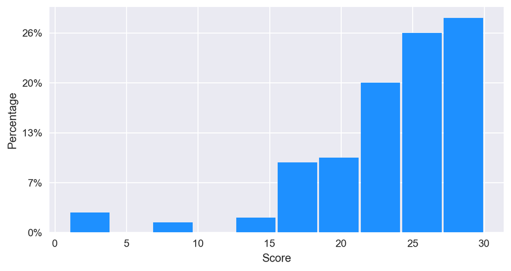

## Assessment Questions

**CODE OF CONDUCT**

- **Use of ChatGPT or similar AI tools is STRICTLY FORBIDDEN in our bi-weekly quizzes.**
- This is a "**limited open-computer**" assessment.
- **You must work on this assessment on your own and you must neither provide nor receive any help from anyone.**
- **You must not share this questions notebook nor your solutions with anyone, neither before submission nor after.**
- Please see Canvas for the full `Code of Conduct`.

**INSTRUCTIONS**

1. You **must not** delete any existing cells in this notebook and you **must not** modify any existing cell tags. If you accidentally delete a cell, you will need to go to the "Edit" menu option and select "Undo Delete Cells".
2. In an answer cell, any direct action **required from you** will be indicated by UPPER CASE PYTHON COMMENTS starting with "###".
3. In general, the value of "999" will denote a dummy placeholder.
4. You **must not change even a single character** in an existing code cell that is **outside** of the "ADD YOUR CODE BELOW/ ABOVE" block.
5. You **must not** have any additional print() statement outputs of your own for any question in your submission.
6. You **must** run each and every one of your answer cells so that your answers are recorded correctly for marking purposes.
7. Please keep in mind that, if you select "*Restart & Clear Output*" or "*Restart & Run All*" from the "*Kernel*" menu option, your answers for any multiple-choice questions will reset to "**nothing selected**".
8. Please see Canvas for additional assessment instructions.
9. This assessment has 11 questions for a total of 30 points.
10. Good luck!

```python
### PLEASE RUN THIS CELL SO THAT THE DROPDOWN ANSWER SELECTIONS BELOW WORK CORRECTLY
### WARNING!! If you restart your kernel, you will need to run this cell again.
from ipywidgets import interactive
def function_mcq(selection): pass
```

```python
### PLEASE FIRST WRITE YOUR FULL NAME AND STUDENT ID BELOW,
### AND THEN EXECUTE THIS CODE CELL.
# Thank you.
print("""
Name:
Student ID:
""")
```

## Question 1 (2 points)

For an answer cell in this notebook, **you must run the cell** so that your answer is recorded correctly for marking purposes. **True** or **False**?

**HINT:** For any answer cell in this notebook, you must run, that is, execute, the cell so that your answer is recorded correctly for marking purposes.

```python
### PLEASE RUN THIS CELL
q1 = interactive(function_mcq,
                 selection=['nothing selected', 'True', 'False']);
display(q1)
```

```python
### PLEASE RUN THIS CELL AFTER YOUR SELECTION ABOVE
print(f"{q1.kwargs['selection']}")
```

**Go to Top**

## Question 2 (2 points)

In this course, what is the maximum number of students allowed in a course project group? Please select the correct answer below.

```python
### PLEASE RUN THIS CELL
q2 = interactive(function_mcq,
                 selection=['nothing selected',
                            'Max project group size is 1. ',
                            'Max project group size is 2. ',
                            'Max project group size is 3. ',
                            'Max project group size is 4. ',
                            'Max project group size is 5. ']);
display(q2)
```

```python
### PLEASE RUN THIS CELL AFTER YOUR SELECTION ABOVE
print(f"{q2.kwargs['selection']}")
```

**Go to Top**

## Question 3 (4 points)

Write a Python program that will ask for two real numbers and print the sum of their respective absolute cubic values. For example, for the inputs of `-2` and `-3`, your program should output 35.

**HINT 1:** The power operator in Python is `**`. That is, `4**2 = 16` and `4**0.5 = 2`.

**HINT 2:** Consider the `abs()` Python function.

```python
a = float(input('Waiting for input: '))
b = float(input('Waiting for input: '))

def my_func(a, b):
    ### ADD YOUR CODE BELOW


    result = 999

    return result

    ### ADD YOUR CODE ABOVE

print(f"the output is {my_func(a,b):.2f}.")
```

**Go to Top**

## Question 4 (2 points)

In this course, how long is the assessment rechecking request window open for? **Please be reminded that you will not be able to request a recheck after this window.** Thank you.

```python
### PLEASE RUN THIS CELL
q4 = interactive(function_mcq,
                 selection=[
                 'nothing selected',
                 '24 hours',
                 '3 calendar days',
                 '5 calendar days',
                 '7 calendar days',
                 '14 calendar days']);
display(q4)
```

```python
### PLEASE RUN THIS CELL AFTER YOUR SELECTION ABOVE
print(f"{q4.kwargs['selection']}")
```

**Go to Top**

## Question 5 (4 points)

Write a Python program that will first ask for a positive integer `n` that is bigger than 5. Then it will print a dictionary that has all the numbers from 5 up to and including `n` as the dictionary keys and their multiple of 2 as the values corresponding to these keys.

For example, for `n=8`, this dictionary needs to be as follows: `{5: 10, 6: 12, 7: 14, 8: 16}`.

```python
n = int(float(input('Waiting for input: ')))

### REQUIREMENT: the name of your dictionary must be "d"

### ADD YOUR CODE BELOW


d = 999

### ADD YOUR CODE ABOVE

print(d)
```

**Go to Top**

## Question 6 (2 points)

Which one of the following is the proper way to communicate with the course staff?

```python
### PLEASE RUN THIS CELL
q6 = interactive(function_mcq,
                 selection=[
                 'nothing selected',
                 'Regular RMIT email',
                 'Your personal email',
                 'Canvas email',
                 'Microsoft Teams chats ',
                 'Via phone']);
display(q6)
```

```python
### PLEASE RUN THIS CELL AFTER YOUR SELECTION ABOVE
print(f"{q6.kwargs['selection']}")
```

**Go to Top**

## Question 7 (4 points)

Write a Python program that, given a string of letters, it will print out the middle letter once in alphabetical order. If the string has an even number of letters, return the earlier middle letter. You program will ask for the list as a user input where the string will be entered **without any spaces or commas!**

For example, your program needs to print:

- `The alphabetical middle letter is c` for the user input `yzabc`
- `The alphabetical middle letter is b` for the user input `abcd`.

**NOTE:** You **may not** use `numpy` or any other modules for this question. You will need to solve this question by using only base Python.

**HINT:** In Python, you can sort a list by the `sorted()` function, which you are allowed to use for this question. You can find more information [here](https://www.featureranking.com/tutorials/python-tutorials/introduction-to-python-programming/).

```python
# get the user input string
input_string = input('Waiting for input: ')  # example: abcd (without any spaces or commas in between)

# split the user input string into a list
string = [letter for letter in input_string]

### ADD YOUR CODE BELOW


middle_letter = 999

### ADD YOUR CODE ABOVE

print(f"The alphabetical middle letter is {middle_letter}.")
```

**Go to Top**

## Question 8 (2 points)

What is the late submission penalty in this course for a course project report?

```python
### PLEASE RUN THIS CELL
q8 = interactive(function_mcq,
                 selection=[
                 'nothing selected',
                 '5 calendar days at 5% penalty per day',
                 '10 calendar days at 5% penalty per day',
                 '5 calendar days at 10% penalty per day',
                 '10 calendar days at 10% penalty per day',
                 ]);
display(q8)
```

```python
### PLEASE RUN THIS CELL AFTER YOUR SELECTION ABOVE
print(f"{q8.kwargs['selection']}")
```

**Go to Top**

## Question 9 (3 points)

Write a Python program that prompts the user to enter a sequence of numbers, separated by spaces, and then determines the second-largest number among these numbers. For simplicity, you can assume that the numbers in the sequence are distinct.

For example, for the input `3 4 7 8 14 6 23`, your program should output 14.

**NOTES:**

- You will need to answer this question using base Python.
- You may NOT use the `scipy` or `numpy` or `pandas` modules for this question.
- You may NOT use the `sort` or `sorted` list functions for this question.
- To be clear, your code must NOT contain any of the above forbidden keywords in an uncommented line.

```python
num_list = input('Waiting for input: ')  # example: 3 4 7 8 14 6 23 (with spaces in between)

# Convert each element in the list to a float
num_list = [float(num) for num in num_list.split()]

# Initialise largest and second_largest
largest = float('-inf')
second_largest = float('-inf')


# Find the largest and second-largest numbers in the list
### ADD YOUR CODE BELOW


second_largest = 999

### ADD YOUR CODE ABOVE


print(f"The second largest number in the list is {second_largest:.2f}")
```

**Go to Top**

## Question 10 (2 points)

In case you need to make an application for a discretionary extension for a course project report, how much in advance do you need to make this application?

```python
### PLEASE RUN THIS CELL
q10 = interactive(function_mcq,
                 selection=[
                 'nothing selected',
                 'At least 2 hours before the deadline ',
                 'At least 24 hours before the deadline ',
                 'At least 1 working day before the deadline ',
                 'At most 24 hours after the deadline ',
                 'At most 2 working days after the deadline ',
                 'At most 5 working days after the deadline ',
                 ]);
display(q10)
```

```python
### PLEASE RUN THIS CELL AFTER YOUR SELECTION ABOVE
print(f"{q10.kwargs['selection']}")
```

**Go to Top**

## Question 11: (Challenge Question) Prime Number Decomposition (3 points)

**This is a Challenge Question, please only attempt this question AFTER the rest of the questions!**

**Also be aware of how much time you have left!**

All positive integers can be expressed as a product of prime numbers. This set of primes are known as the prime number decomposition for a given number. Note that the prime number decomposition is unique for any given number.

For instance, the number $12$ can be expressed as the product of primes of $2\times2\times3$ so the prime number decomposition for the number $12$ is $2$, $2$ and $3$. Similarly, for prime numbers the prime number decomposition is the number itself, that is the prime number decomposition for $5$ is $5$.

Write a Python function that takes in a positive integer bigger than 2 and returns a sorted list (in ascending order) of the prime number decomposition for the given integer.

You can use the `is_prime()` function given below for your convenience.

```python
n = int(float(input('Waiting for input: ')))  # example: 12


def is_prime(n):
    for i in range(2, int(n**0.5)+1):
        if n % i == 0:
            return False
    return True


def PND(n):

    # initialise prime list to an empty list
    prime_lst = []

    ### ADD YOUR CODE BELOW


    ### ADD YOUR CODE ABOVE

    return prime_lst


print(f'The prime number decomposition of {n} is {PND(n)}.')
```

**Go to Top**

Marking & Feedback by **[SageGrader.com](https://sagegrader.com)**: The Sage Way To Grade.